# Analyzing Racial Disparities in NYPD ‘Level 3’ Stop-and-Frisk Civilian Interactions

## Visualizing Bias

Mapping the census tracts with confirmed significant bias is essential to fully explore the issue. The census tracts are clustered in one neighborhood, or police precinct, the bias becomes a more localized phenomenon. Such a result would indicate that the issue is not perpetrated by the NYPD as a whole.

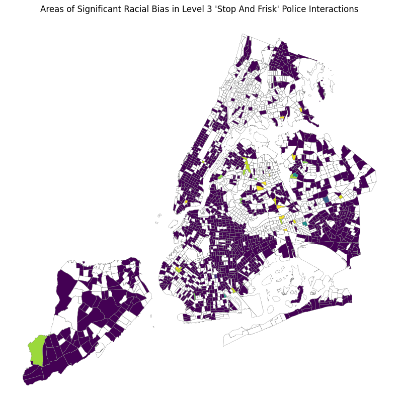

Census Tracts of Significant Racial Bias in ‘Stop And Frisk’ NYPD Interactions

When mapped the results do not reveal any sort of localization. The figure above show a map of New York City, drawn with the lines of the census tract areas, and shaded to indicate the severity of the bias found in the Level 3 stops in that tract.

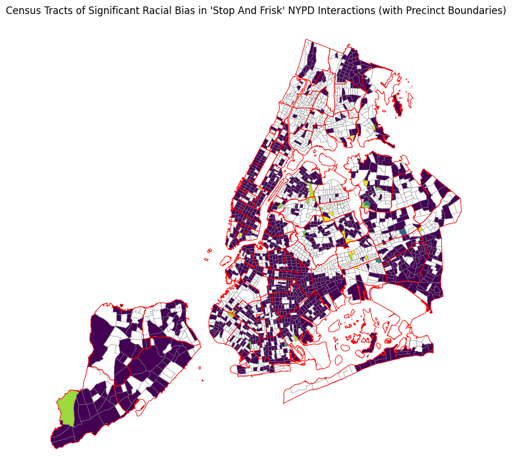

Census Tracts of Significant Racial Bias in ‘Stop And Frisk’ NYPD Interactions (with Precinct Boundaries)

A overlaid map of police precincts reveals what was already evident. The ‘bad apples’ of the police force are actually all the apples - or at least, many of them. Enough that every precinct is affected enough to have an purple, ‘off the charts’ census tract inside of it. And with more than 30,000 Level 3 interactions included in the data, this much widespread bias cannot be perpetrated by just a few individuals, even if they’re distributed through the precincts evenly. It reflects a societal and systemic violence that is exacerbated by something in the NYPD officer experience.

## Conclusion

The findings of this analysis are consistent with all previous examination of persistent issue of discriminatory policing practices within the New York City Police Department (NYPD). Despite efforts to reform stop-and-frisk procedures following a federal court ruling over a decade ago, there has been no change in racial bias and racial profiling.

The overlay of police precincts on a map vividly illustrates the widespread nature of bias within the NYPD. Rather than isolated incidents involving a few “bad apples,” the data suggests systemic issues that permeate every precinct. The sheer volume of Level 3 interactions documented in the data—exceeding 30,000—underscores the magnitude of the problem. Such pervasive bias cannot be attributed solely to individual officers but reflects broader societal and systemic challenges within the NYPD.

Additional analysis on this issue could include broadening the scope of the data that is analyzed in this way. What are the geospatial dimensions of arrests? Of traffic stops? These could become a broader analysis of the impact on the NYPD on the city, and does whether whatever good the organization does do outweigh the harm caused by the undeniable profiling to the larger NYC population.

### References

1. New York City Police Department. (n.d.). *NYPD Stop, Question, and Frisk database*.(2023, 2022) Retrieved from https://www.nyc.gov/site/nypd/stats/reports-analysis/stopfrisk.page
2. U.S. Census Bureau. (2020). *RACE*. Decennial Census, DEC Redistricting Data (PL 94-171), Table P1. Retrieved May 12, 2024, from https://data.census.gov/table/DECENNIALPL2020.P1
3. NYC OpenData. (2024). *Police Precincts [GIS data]*. Department of City Planning (DCP). https://data.cityofnewyork.us/Public-Safety/Police-Precincts/78dh-3ptz
4. NYC OpenData. (2024). *2020 Census Tracts [GIS data]*. United States Census Bureau. https://data.cityofnewyork.us/City-Government/2020-Census-Tracts-Mapped/weqx-t5xr
5. Jordahl, K., Van den Bossche, J., Fleischmann, M., Wasserman, J., McBride, J., Gerard, J., Tratner, J., Perry, M., Garcia Badaracco, A., Farmer, C., Hjelle, G. A., Snow, A. D., Cochran, M., Gillies, S., Culbertson, L., Bartos, M., Eubank, N., Albert, M., Bilogur, A., Rey, S., Ren, C., Arribas-Bel, D., Wasser, L., Wolf, L. J., Journois, M., Wilson, J., Greenhall, A., Holdgraf, C., Filipe, & Leblanc, F. (2020). *geopandas/geopandas*: v0.8.1 [Software]. Zenodo. https://doi.org/10.5281/zenodo.3946761